# Basketball Training

Author

Erik-Jan van Kesteren

## Introduction

I was on holiday and had to wait a while. Fortunately, close to where I was sitting there was a kid playing basketball all by himself. Of course I had to record how many hits and misses he made, to keep it as a nice dataset for further analysis.

Here is the dataset:

```r
basket <- c("miss","miss","miss","hit","miss","hit","miss", "miss",
            "hit","hit","miss","miss","miss","miss", "miss","miss",
            "miss","hit","hit","hit","miss","hit")
```

## What can we do with this?

Firstly, we can describe how often the kid manages to score a point:

[figure not shown]

So it looks like the kid misses a bit more than he hits. But there is much more information in this dataset: besides whether the kid hits or misses, we can say something about the *sequence* of these events.

## Transition matrix

From a sequence of observations, it is possible to construct a transition matrix

$$\begin{bmatrix}
A & B \\
C & D
\end{bmatrix}$$
Where the elements indicate the probability that:

- $A$: a hit is followed by another hit
- $B$: a hit is followed by a miss!
- $C$: a miss is followed by a hit
- $D$: a miss is followed by another miss

If we don’t know the true probabilities, we can enter the observed probabilities into the matrix. Here is an `R` function for generating the transition matrix from the data vector of before:

```r
transMat <- function(x, prob = TRUE) {
  X <- t(as.matrix(x))
  tt <- table( c(X[,-ncol(X)]), c(X[,-1]) )
  if (prob) tt <- tt / rowSums(tt)
  tt
}

transitionMatrix <- transMat(basket)
print(transitionMatrix, digits = 2)
```

```
        hit miss
  hit  0.43 0.57
  miss 0.36 0.64
```

## Markov chain

This transition matrix completely defines the 2-state markov chain. Assuming these probabilities are stable, we can now generate processes just like the one we observed. And we can nicely visualise it using [this markov chain generator post](http://setosa.io/ev/markov-chains/) by [setosa](http://setosa.io/ev/). Go to [this link](http://setosa.io/markov/index.html#%7B%22tm%22%3A%5B%5B0.43%2C0.57%5D%2C%5B0.36%2C0.64%5D%5D%7D) to play around!

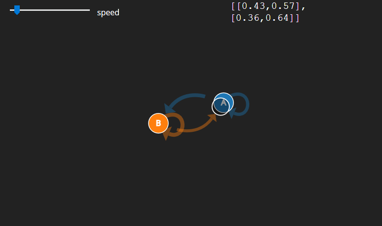

## Steady state

If we assume this chain is stable over time, there is another nice property. Irrespective of the initial probabilities of hitting or missing that we choose, after a few steps of the markov process, the probability of hitting the basket already converges to the *steady state*:

[figure not shown]

In general, we can calculate the steady state easily from the transition matrix:

```r
someBigNumber <- 1000
diag(transitionMatrix %^% someBigNumber)
```

```
      hit      miss
0.3846154 0.6153846
```

Note that this leads to a similar but different result than simply counting the probability of hitting or missing as a table, as we did in the first figure:

```r
table(basket)/length(basket)
```

```
basket
      hit      miss
0.3636364 0.6363636
```

# Questions

- What should we trust here? The naïve probabilities or the markov steady state?
- Which assumptions lead to this discrepancy?
- Does the transition matrix really contain more relevant information about this process than the observed hit rate?